# Importing updated COVID Stringency data

```r
library(tidyverse)
```

We would like to consider updating our analysis to include 2021 data, and to that end we need updated COVID stringency data, as the current file only goes to April 2021. Unfortunately, the `xlsx` format data we have has not been updated, and there is a csv we need to import:

```r
stringency_latest <- read_csv("OxCGRT_US_latest.csv")
```

```r
names(stringency_latest)
```

```
 [1] "CountryName"                           "CountryCode"
 [3] "RegionName"                            "RegionCode"
 [5] "Jurisdiction"                          "Date"
 [7] "C1_School closing"                     "C1_Flag"
 [9] "C1_Notes"                              "C2_Workplace closing"
[11] "C2_Flag"                               "C2_Notes"
[13] "C3_Cancel public events"               "C3_Flag"
[15] "C3_Notes"                              "C4_Restrictions on gatherings"
[17] "C4_Flag"                               "C4_Notes"
[19] "C5_Close public transport"             "C5_Flag"
[21] "C5_Notes"                              "C6_Stay at home requirements"
[23] "C6_Flag"                               "C6_Notes"
[25] "C7_Restrictions on internal movement"  "C7_Flag"
[27] "C7_Notes"                              "C8_International travel controls"
[29] "C8_Notes"                              "E1_Income support"
```

[output cut: 25 more lines]

Let me just grab the columns we care about:

```r
stringency_latest <- stringency_latest %>%
  select(CountryName, CountryCode, RegionName, RegionCode, Jurisdiction, Date,
         StringencyIndex, StringencyLegacyIndex)

stringency_latest %>% head()
```

| CountryName | CountryCode | RegionName | RegionCode | Jurisdiction | Date | StringencyIndex | StringencyLegacyIndex |
| --- | --- | --- | --- | --- | --- | --- | --- |
| United States | USA | NA | NA | NAT_GOV | 20200101 | 0 | 0 |
| United States | USA | NA | NA | NAT_GOV | 20200102 | 0 | 0 |
| United States | USA | NA | NA | NAT_GOV | 20200103 | 0 | 0 |
| United States | USA | NA | NA | NAT_GOV | 20200104 | 0 | 0 |
| United States | USA | NA | NA | NAT_GOV | 20200105 | 0 | 0 |
| United States | USA | NA | NA | NAT_GOV | 20200106 | 0 | 0 |

Let me re-format some of these columns:

But first check what values there are for jurisdiction…

```r
stringency_latest %>%
  select(Jurisdiction) %>% distinct()
```

| Jurisdiction |
| --- |
| NAT_GOV |
| STATE_WIDE |

And values for RegionName:

```r
stringency_latest %>%
  select(RegionName) %>% distinct()
```

| RegionName |
| --- |
| NA |
| Alaska |
| Alabama |
| Arkansas |
| Arizona |
| California |
| Colorado |
| Connecticut |
| Washington DC |
| Delaware |

[output cut: 42 more lines]

It has the 50 states, plus DC and some NA values.

```r
stringency_latest <- stringency_latest %>%
  rename(State = RegionName) %>%
  mutate(Year = as.integer((substr(Date, start = 1, stop = 4))),
         Month = substr(Date, start = 5, stop = 6),
         Day = substr(Date, start = 7, stop = 8)) %>%
  select(State, Year, Month, Day, StringencyIndex, StringencyLegacyIndex)

stringency_latest %>% head()
```

| State | Year | Month | Day | StringencyIndex | StringencyLegacyIndex |
| --- | --- | --- | --- | --- | --- |
| NA | 2020 | 01 | 01 | 0 | 0 |
| NA | 2020 | 01 | 02 | 0 | 0 |
| NA | 2020 | 01 | 03 | 0 | 0 |
| NA | 2020 | 01 | 04 | 0 | 0 |
| NA | 2020 | 01 | 05 | 0 | 0 |
| NA | 2020 | 01 | 06 | 0 | 0 |

Lets collapse to the month level and compare values:

```r
stringency_monthly <- stringency_latest %>%
  group_by(State, Year, Month) %>%
  summarise(Stringency = sum(StringencyIndex),
            StringencyLegacy = sum(StringencyLegacyIndex),
            .groups = "drop")

stringency_monthly
```

| State | Year | Month | Stringency | StringencyLegacy |
| --- | --- | --- | --- | --- |
| Alabama | 2020 | 01 | 0.00 | 0.00 |
| Alabama | 2020 | 02 | 0.00 | 0.00 |
| Alabama | 2020 | 03 | 819.88 | 861.21 |
| Alabama | 2020 | 04 | 1949.51 | 2147.65 |
| Alabama | 2020 | 05 | 1639.72 | 1835.60 |
| Alabama | 2020 | 06 | 1143.45 | 1607.10 |
| Alabama | 2020 | 07 | 1119.41 | 1660.67 |
| Alabama | 2020 | 08 | 1063.89 | 1584.51 |
| Alabama | 2020 | 09 | 901.85 | 1357.20 |
| Alabama | 2020 | 10 | 918.53 | 1402.44 |

[output cut: 990 more lines]

These values are, unfortunately, not matching up with the values from the prior data. However, I have figured out the problem. The old values we had were the sum of the state-specific indices and the national value.

I need to get the national values of stringency for each date:

```r
national_stringency <- stringency_latest %>%
  filter(is.na(State)) %>%
  select(Year, Month, Day, StringencyIndex) %>%
  rename(NationalStringencyIndex = StringencyIndex)

national_stringency
```

| Year | Month | Day | NationalStringencyIndex |
| --- | --- | --- | --- |
| 2020 | 01 | 01 | 0.00 |
| 2020 | 01 | 02 | 0.00 |
| 2020 | 01 | 03 | 0.00 |
| 2020 | 01 | 04 | 0.00 |
| 2020 | 01 | 05 | 0.00 |
| 2020 | 01 | 06 | 0.00 |
| 2020 | 01 | 07 | 0.00 |
| 2020 | 01 | 08 | 0.00 |
| 2020 | 01 | 09 | 0.00 |
| 2020 | 01 | 10 | 0.00 |

[output cut: 798 more lines]

I can now add these to the state values for each state, and collapse to the monthly level:

```r
stringency_monthly <- stringency_latest %>%
  filter(!is.na(State)) %>%
  left_join(national_stringency, by = c("Year", "Month", "Day")) %>%
  mutate(StringencyIndex = StringencyIndex + NationalStringencyIndex) %>%
  group_by(State, Year, Month) %>%
  summarise(Stringency = sum(StringencyIndex),
            .groups = "drop")

stringency_monthly
```

| State | Year | Month | Stringency |
| --- | --- | --- | --- |
| Alabama | 2020 | 01 | 0.00 |
| Alabama | 2020 | 02 | 0.00 |
| Alabama | 2020 | 03 | 1575.36 |
| Alabama | 2020 | 04 | 3192.19 |
| Alabama | 2020 | 05 | 2931.49 |
| Alabama | 2020 | 06 | 2393.55 |
| Alabama | 2020 | 07 | 2411.18 |
| Alabama | 2020 | 08 | 2240.65 |
| Alabama | 2020 | 09 | 2040.65 |
| Alabama | 2020 | 10 | 2095.29 |

[output cut: 990 more lines]

This also does not match up with the old data. After some extensive investigation, I have figured out the problem. There are 2 versions of the COVID stringnecy index for US states, and I am looking at the wrong one, or at least a different one than we had for the old data.

The data I have downloaded and investigated is the one here:

https://github.com/OxCGRT/USA-covid-policy

This is a USA-specific data repo

And the data that matches the old data we have been using for the paper is here:

https://github.com/OxCGRT/covid-policy-tracker

The difference between the stringency indices provided by the files in these 2 different repos (general repo and US repo) is that the general repo accounts for national policies in calculating the state-specific stringency index, while the US specific repo does not. In particular, the general repo replaces component scores for state-days where the national policy on that day is more stringent than the state policy. For instance, for the travel indicator component of the index, if Alabama had a 2 and Maine had 4, and the US policy was a 3, then under the general repos methodology Alabama would have a 3 and Maine would have a 4, while under the US repo’s methodology, Alabama would retain its 2.

In order to be consistent with the old data, we need to use the general repo’s data. However, I wonder if this strategy is not masking some meaningful variation in state policies, especially considering that US Federal policy was certainly not meaningfully adhered to in many states…. It may be worth using both versions of the index and comparing results, and also I should dig more into the discrepancies and try to reason through which methodology is more appropriate based on that.

```r
stringency_global <- read_csv("OxCGRT_latest.csv")
```

Get just the US state-specific data:

```r
stringency_us <- stringency_global %>%
  filter(CountryCode == "USA") %>%
  rename(State = RegionName) %>%
  mutate(Year = as.integer((substr(Date, start = 1, stop = 4))),
         Month = substr(Date, start = 5, stop = 6),
         Day = substr(Date, start = 7, stop = 8)) %>%
  select(State, Year, Month, Day, StringencyIndex)

stringency_us
```

| State | Year | Month | Day | StringencyIndex |
| --- | --- | --- | --- | --- |
| NA | 2020 | 01 | 01 | 0.00 |
| NA | 2020 | 01 | 02 | 0.00 |
| NA | 2020 | 01 | 03 | 0.00 |
| NA | 2020 | 01 | 04 | 0.00 |
| NA | 2020 | 01 | 05 | 0.00 |
| NA | 2020 | 01 | 06 | 0.00 |
| NA | 2020 | 01 | 07 | 0.00 |
| NA | 2020 | 01 | 08 | 0.00 |
| NA | 2020 | 01 | 09 | 0.00 |
| NA | 2020 | 01 | 10 | 0.00 |

[output cut: 990 more lines]

Collapse to monthly level:

```r
stringency_us_monthly <- stringency_us %>%
  group_by(State, Year, Month) %>%
  summarise(Stringency = sum(StringencyIndex),
            .groups = "drop")

stringency_us_monthly
```

| State | Year | Month | Stringency |
| --- | --- | --- | --- |
| Alabama | 2020 | 01 | 0.00 |
| Alabama | 2020 | 02 | 0.00 |
| Alabama | 2020 | 03 | 1195.80 |
| Alabama | 2020 | 04 | 2366.21 |
| Alabama | 2020 | 05 | 2070.31 |
| Alabama | 2020 | 06 | 1560.15 |
| Alabama | 2020 | 07 | 1550.00 |
| Alabama | 2020 | 08 | 1494.48 |
| Alabama | 2020 | 09 | 1318.55 |
| Alabama | 2020 | 10 | 1349.12 |

[output cut: 990 more lines]

Let me compare these with the old values:

```r
tripsTMPS_p <- readRDS("tripsTMPS.rds") %>% filter(Mode == "7")

stringency_us_monthly %>%
  left_join(tripsTMPS_p, by = c("State", "Year", "Month")) %>%
  filter(!is.na(Stringency.y)) %>%
  filter(Stringency.x != Stringency.y) %>%
  select(State, Year, Month, Stringency.x, Stringency.y)
```

| State | Year | Month | Stringency.x | Stringency.y |
| --- | --- | --- | --- | --- |
| Alabama | 2020 | 02 | 0.00 | 155.68 |
| Alabama | 2020 | 03 | 1195.80 | 1201.36 |
| Connecticut | 2020 | 02 | 183.44 | 338.88 |
| Connecticut | 2020 | 03 | 1519.86 | 1525.42 |
| Delaware | 2020 | 02 | 224.95 | 316.64 |
| Delaware | 2020 | 03 | 1556.48 | 1559.26 |
| Florida | 2020 | 02 | 27.80 | 183.43 |
| Florida | 2020 | 03 | 1507.80 | 1513.36 |
| Georgia | 2020 | 02 | 0.00 | 155.68 |
| Georgia | 2020 | 03 | 996.27 | 1001.83 |

[output cut: 30 more lines]

There are 40 state-months where there is some discrepancy between this updated data, and the old data we had been using, mostly in February and March. Specifically:

```r
stringency_us_monthly %>%
  left_join(tripsTMPS_p, by = c("State", "Year", "Month")) %>%
  filter(!is.na(Stringency.y)) %>%
  filter(Stringency.x != Stringency.y) %>%
  select(State, Year, Month, Stringency.x, Stringency.y) %>%
  count(Month)
```

| Month | n |
| --- | --- |
| 02 | 16 |
| 03 | 16 |
| 04 | 2 |
| 08 | 1 |
| 09 | 1 |
| 10 | 1 |
| 11 | 1 |
| 12 | 2 |

80% of these discrepancies are from Feb and March 2020, with others randomly throughout the year.

Plotting:

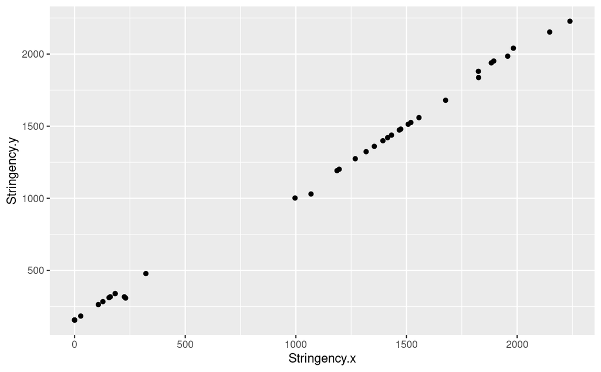

```r
stringency_us_monthly %>%
  left_join(tripsTMPS_p, by = c("State", "Year", "Month")) %>%
  filter(!is.na(Stringency.y)) %>%
  filter(Stringency.x != Stringency.y) %>%
  select(State, Year, Month, Stringency.x, Stringency.y) %>%
  ggplot(aes(Stringency.x, Stringency.y)) + geom_point()
```

These are clearly very minor discrepancies, and I feel fine treating this new data as essentially the same as the old data for all practical purposes.

Let me sum up with all the code needed to get to the monthly dataset:

```r
read_csv("OxCGRT_latest.csv") %>%
  filter(CountryCode == "USA") %>%
  rename(State = RegionName) %>%
  mutate(Year = as.integer((substr(Date, start = 1, stop = 4))),
         Month = substr(Date, start = 5, stop = 6)) %>%
  group_by(State, Year, Month) %>%
  summarise(Stringency = sum(StringencyIndex),
            .groups = "drop")
```

| State | Year | Month | Stringency |
| --- | --- | --- | --- |
| Alabama | 2020 | 01 | 0.00 |
| Alabama | 2020 | 02 | 0.00 |
| Alabama | 2020 | 03 | 1195.80 |
| Alabama | 2020 | 04 | 2366.21 |
| Alabama | 2020 | 05 | 2070.31 |
| Alabama | 2020 | 06 | 1560.15 |
| Alabama | 2020 | 07 | 1550.00 |
| Alabama | 2020 | 08 | 1494.48 |
| Alabama | 2020 | 09 | 1318.55 |
| Alabama | 2020 | 10 | 1349.12 |

[output cut: 990 more lines]